# 09_B_ResidualsAnalysis

# References

1. Hyndman, R.J., & Athanasopoulos, G., 2021. *Forecasting: principles and practice*. 3rd edition.
2. Fable package documentation
   - [Link 1](https://fable.tidyverts.org/index.html)
   - [Link 2](https://fable.tidyverts.org/articles/fable.html)
3. Bonar, P. A. J., Goodall, G. J., & Armstrong, S. D. (2019). *Exploring seasonality and periodicity in time series data*. National Center for Biotechnology Information (NCBI). Available at: [Link](https://www.ncbi.nlm.nih.gov/pmc/articles/PMC6337927/)
4. Khomyanin, I. (2024, May 17). *Tales of the Undead Salmon: Exploring Bonferroni Correction in Multiple Hypothesis Testing*. HackerNoon. Available at: [Link](https://hackernoon.com/tales-of-the-undead-salmon-exploring-bonferroni-correction-in-multiple-hypothesis-testing)

# Libraries

```r
library(fpp3)
library(patchwork)
```

# Residual diagnostics

In time series, a fitted value is a one-step-ahead forecast on the training data. If the training data runs from $t=1$ to $t=T$:

$$\text{fitted values: } \ \ \ \ \hat{y}_{t|t-1} \ \ \ \ 1 \leq t \leq T$$

So the residuals are:

$$\text{residuals: } \ \ \ \ y_t - \hat{y}_{t|t-1} \ \ \ \ 1 \leq t \leq T$$

We check four properties of the residuals:

1. No autocorrelation: no information is left in the residuals.
2. Zero mean: the forecasts are not biased.
3. Constant variance: the spread of the residuals does not change over time.
4. Normal distribution.

The summary sheet `09_A` in this folder covers all four on one page. In short:

**1 and 2 are about the model.** A model that fails either can be improved. Often several models pass both, and then you need to choose among them, with tools such as cross-validation and information criteria later in the course.

- A non-zero mean (bias) is easy to fix: add the mean of the residuals to the forecasts. A residual is the observation minus its fitted value, so residuals that average $m$ mean the forecasts sit $m$ too low.
- Autocorrelation left in the residuals is harder to fix. You may need autoregressive terms, external regressors, or a different model.

**3 and 4 are about the prediction intervals.**

- A transformation, most often Box-Cox (Session 11), is usually the only way to improve these two. If it does not work, changing the model may be the best option.
- [Bootstrapped](https://otexts.com/fpp3/prediction-intervals.html) prediction intervals do not need normal residuals, only uncorrelated residuals with constant variance.

Read [fpp3 section 5.4](https://otexts.com/fpp3/diagnostics.html) and the summary sheet `09_A`.

# Example 1: brick production

```r
bricks <- aus_production |>
  filter_index("1970 Q1" ~ "2004 Q4") |> # Shorthand for filtering data between 1970 and 2004
  select(Bricks)
```

Here one call to `model()` fits two models. The result is a model table, a `mable`, with one column per model.

```r
bricks_fit <- bricks |> model(
                                Mean = MEAN(Bricks), # Fit two models at once
                                Nv = NAIVE(Bricks)
                               )

bricks_fit
```

```
# A mable: 1 x 2
     Mean      Nv
  <model> <model>
1  <MEAN> <NAIVE>
```

`augment()` returns the fitted values and residuals of every model in the `mable`, next to the original data:

```r
model_vals <-
  bricks_fit |>
  augment()

model_vals
```

```
# A tsibble: 280 x 6 [1Q]
# Key:       .model [2]
   .model Quarter Bricks .fitted .resid .innov
   <chr>    <qtr>  <dbl>   <dbl>  <dbl>  <dbl>
 1 Mean   1970 Q1    386    451. -64.9  -64.9
 2 Mean   1970 Q2    428    451. -22.9  -22.9
 3 Mean   1970 Q3    434    451. -16.9  -16.9
 4 Mean   1970 Q4    417    451. -33.9  -33.9
 5 Mean   1971 Q1    385    451. -65.9  -65.9
 6 Mean   1971 Q2    433    451. -17.9  -17.9
 7 Mean   1971 Q3    453    451.   2.12   2.12
 8 Mean   1971 Q4    436    451. -14.9  -14.9
 9 Mean   1972 Q1    399    451. -51.9  -51.9
10 Mean   1972 Q2    461    451.  10.1   10.1
# ℹ 270 more rows
```

There is one row per quarter per model: 140 quarters times 2 models gives 280 rows. The `.model` column says which model each row belongs to, which is why most steps below start with `filter(.model == ...)`.

- `Bricks`: the original series, kept as it was.
- `.fitted`: the fitted value, a one-step forecast $\hat{y}_{t|t-1}$. The naive model has none for the first quarter, so its first row is `NA`.
- `.resid`: the residual, `Bricks - .fitted`.
- `.innov`: the innovation residual. With no transformation it equals `.resid`. The checks below use `.innov`.

The original series is used once more, in the plot below, to show the fitted values against the data. From the residual panels on, every check reads `.innov` only: the four properties are properties of the residuals, not of the series.

## Mean model

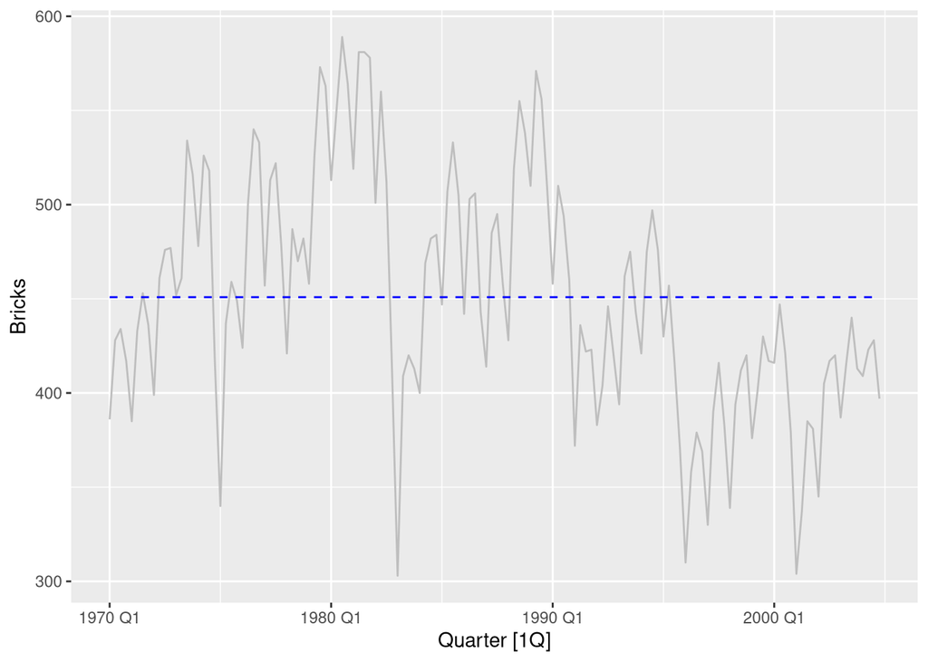

```r
model_vals |>
  filter(.model == "Mean") |>
  autoplot(Bricks, colour = "gray") +
  geom_line(aes(y=.fitted), colour = "blue", linetype = "dashed")
```

In the mean model, every fitted value is the mean of the training data. So the residuals are:

$$\text{residuals} = y_t - mean(y_t)$$

### Residual panels

`gg_tsresiduals()` draws three panels for a quick first look at the residuals: the residuals over time, their ACF plot and their histogram.

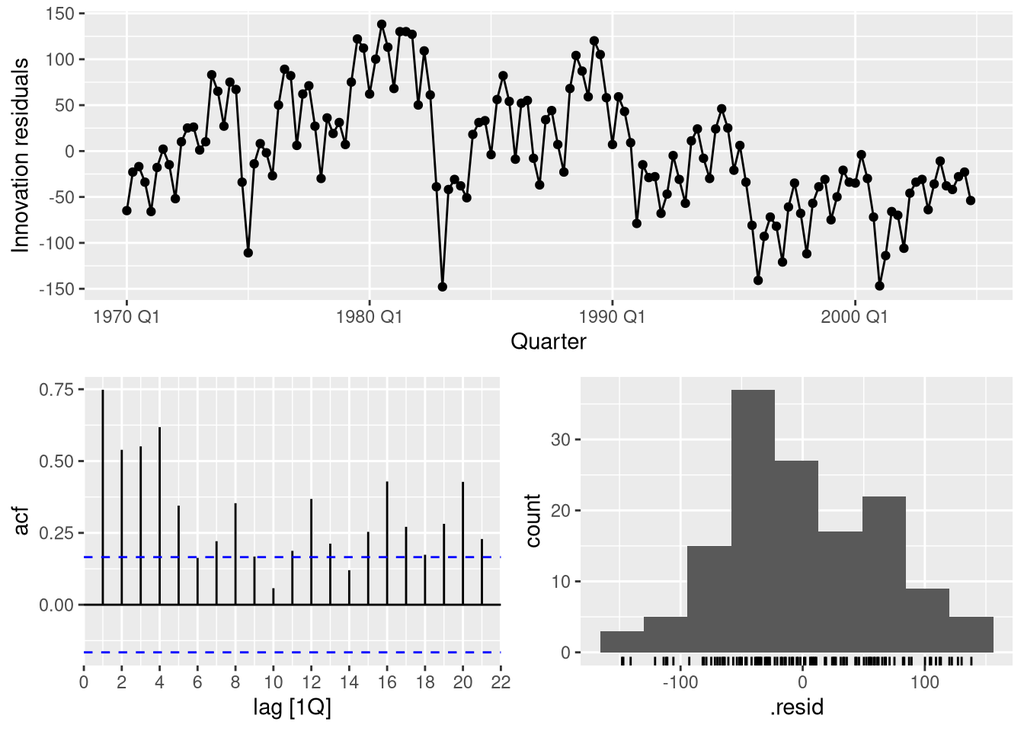

```r
bricks_fit |>
  select(Mean) |> # Selects the Mean model
  gg_tsresiduals()
```

```r
# Compute the mean of the residuals
model_vals |> as_tibble() |>
  filter(.model == "Mean") |>
  summarise(mean = mean(.innov, na.rm = TRUE))
```

```
# A tibble: 1 × 1
       mean
      <dbl>
1 -4.86e-15
```

The residuals of the mean model have the same shape as the data. They are the series minus its mean, so they are the same series centered on zero, just as subtracting the mean centered a series in the classical decomposition.

So the mean model is a clear example of residuals that are **unbiased** (mean 0) but **correlated**.

### QQ plot and boxplot

For normality, a QQ plot and a boxplot of the residuals. The red dot in the boxplot is the mean, so you can compare it with the median. If you have not met QQ plots before, see the *Definition and construction* and *Interpretation* sections of [Wikipedia’s Q-Q plot article](https://en.wikipedia.org/wiki/Q%E2%80%93Q_plot).

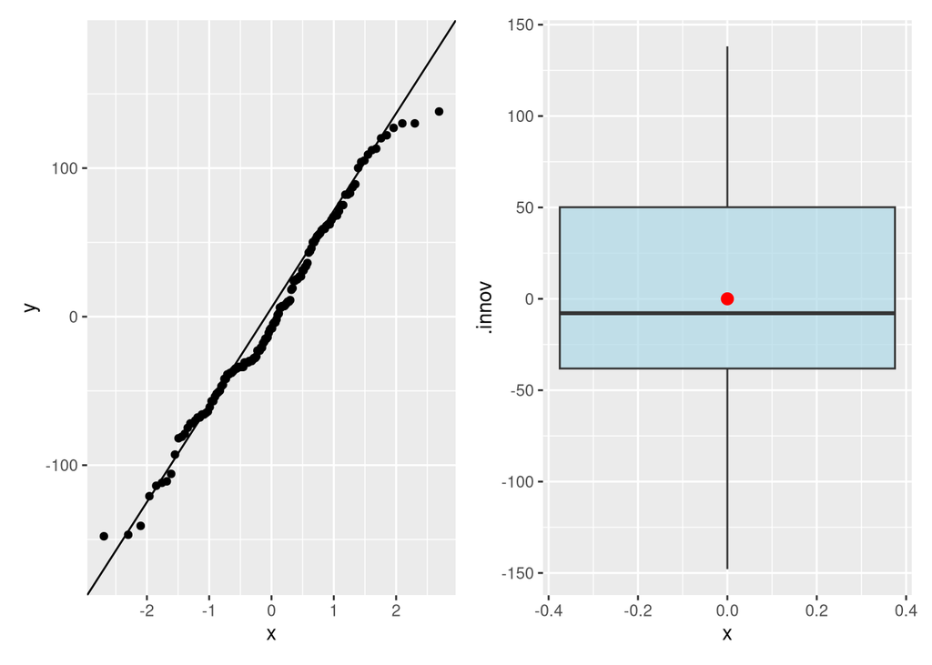

```r
mean_vals <- filter(model_vals, .model=="Mean")

# QQ plot
p1 <- ggplot(mean_vals, aes(sample = .innov))
p1 <- p1 + stat_qq() + stat_qq_line()

# Boxplot
p2 <- ggplot(data = mean_vals, aes(y = .innov)) +
      geom_boxplot(fill="light blue", alpha = 0.7) +
      stat_summary(aes(x=0), fun="mean", colour= "red") # Include the mean

p1 + p2
```

### Boxplots by year

To judge whether the variance is constant, draw one boxplot per year and compare their heights.

One boxplot per year:

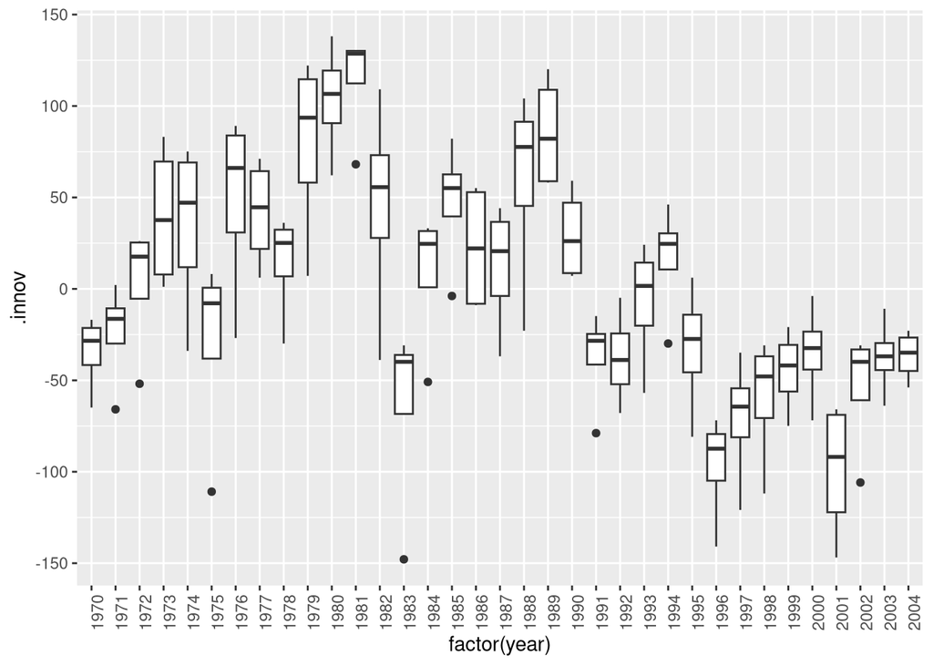

```r
model_vals <-

  model_vals |>

  # Add a column with the year of each observation
  mutate(
    year = year(Quarter),
    year_group = floor((year - 1970) / 2) * 2 + 1970 # Group two consecutive years
  )

# One boxplot per year
model_vals |>

  # Select the appropriate model within model vals
  filter(.model == "Mean") |>

  # Draw the boxplots
  ggplot(aes(x = factor(year), y = .innov)) +
  geom_boxplot() +
  theme(axis.text.x=element_text(angle = 90))
```

One boxplot per two years:

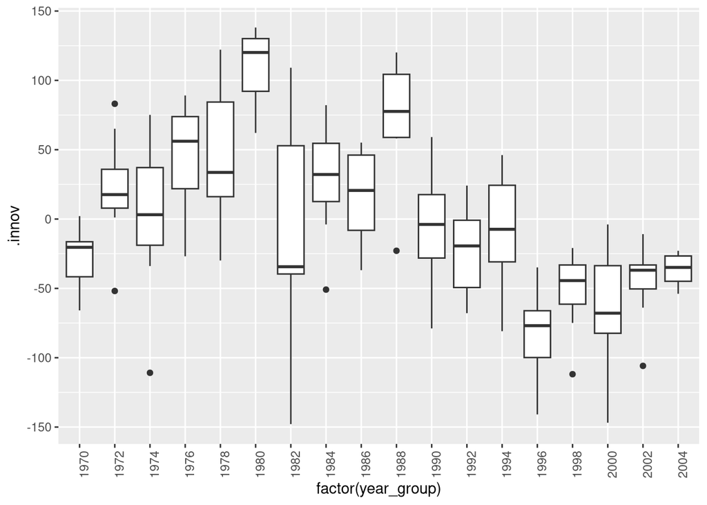

```r
model_vals |>

  # Select the appropriate model within model vals
  filter(.model == "Mean") |>

  # Draw the boxplots
  ggplot(aes(x = factor(year_group), y = .innov)) +
  geom_boxplot() +
  theme(axis.text.x=element_text(angle = 90))
```

### Reading the four properties

1. **Autocorrelation:** strong. Many bars of the ACF plot fall outside the dashed bounds.
   - The model is too simple: the residuals look exactly like the series, shifted down by its mean. They keep the trend and every other feature of the data.
   - The model uses almost none of the information in the data. Fixing this means changing the model.
2. **Mean:** zero, because the residuals are the series minus its own mean.
3. **Variance:** not constant. In recessions, such as 1974 and 1982, the residuals vary much more.
   - In this course we judge constant variance by eye. Formal tests exist for when the plots leave you unsure.
4. **Normality:** roughly normal. The histogram is close to bell-shaped, and the points follow the QQ line except at the tails and a little in the middle. The boxplot is fairly symmetric, with the mean close to the median.
   - A formal normality test exists, but this course judges normality by eye.

## Naive model

The naive model’s fitted value is the previous observation. Its forecast equation is:

$$\text{forecast equation Naive model: } \ \ \hat{y}_{T+h|T} = y_T$$

A fitted value is a one-step-ahead forecast, so set $h=1$:

$$\text{forecast equation for h=1:} \hat{y}_{T+1|T} = y_T$$

To write this as the fitted value at time $t$, let $t=T+1$, so $T=t-1$:

$$\text{fitted value at t:} \ \ \ \ \hat{y}_{t|t-1} = y_{t-1}$$

So **the residuals of the naive model** are:

$$\text{residuals of the naive model:} \ \ \ \ y_t - \hat{y}_{t|t-1} = y_t - y_{t-1}$$

This has an important consequence. If the residuals of the naive model are uncorrelated, as we want them to be, then:

$$y_t - y_{t-1} = \varepsilon_t$$

Solve for $y_t$ and you get a **random walk**: each value is the previous value plus a random shock $\varepsilon_t$.

$$y_t = y_{t-1} + \varepsilon_t$$

This makes the naive model a strong benchmark for many stock prices, where the change from one day to the next is close to uncorrelated: many prices behave much like a random walk. This is related to the efficient market hypothesis.

In general, if the last value is a good guess for the next one, the naive model is a good benchmark.

### Residual panels

Now the naive model on the bricks data:

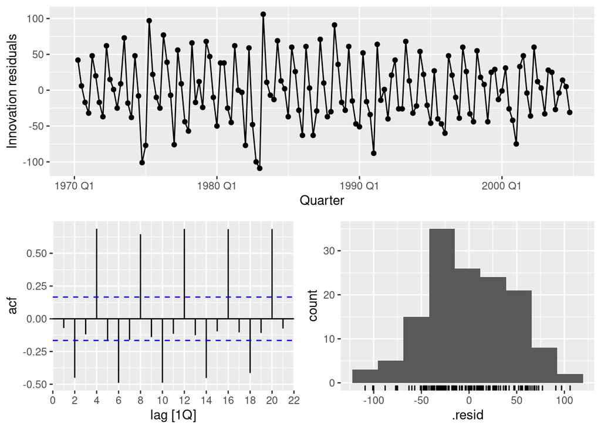

```r
bricks_fit |>
  select(Nv) |>
  gg_tsresiduals()
```

```r
# Compute the mean of the residuals
model_vals |> as_tibble() |>
  filter(.model == "Nv") |>
  summarise(mean = mean(.innov, na.rm = TRUE))
```

```
# A tibble: 1 × 1
    mean
   <dbl>
1 0.0791
```

### QQ plot and boxplot

A QQ plot and a boxplot of the residuals. The red dot in the boxplot is the mean.

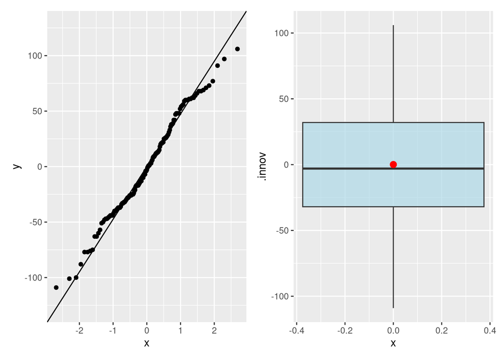

```r
mean_vals <- filter(model_vals, .model=="Nv")

# QQ plot
p1 <- ggplot(mean_vals, aes(sample = .innov))
p1 <- p1 + stat_qq() + stat_qq_line()

# Boxplot
p2 <- ggplot(data = mean_vals, aes(y = .innov)) +
      geom_boxplot(fill="light blue", alpha = 0.7) +
      stat_summary(aes(x=0), fun="mean", colour= "red") # Include the mean

p1 + p2
```

### Boxplots by year

One boxplot per year:

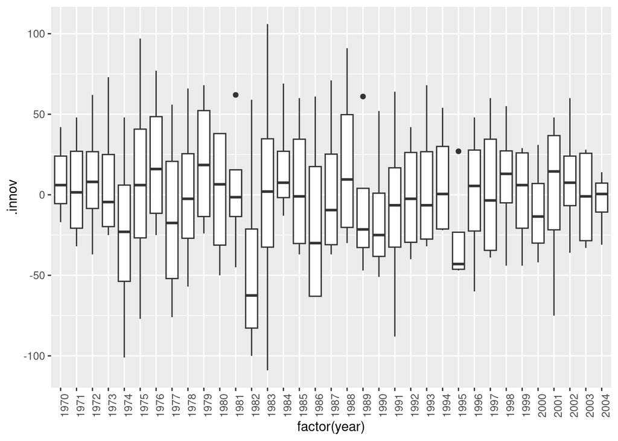

```r
model_vals <-

  model_vals |>

  # Add a column with the year of each observation
  mutate(
    year = year(Quarter),
    year_group = floor((year - 1970) / 2) * 2 + 1970 # Group two consecutive years
  )


# One boxplot per year
model_vals |>

  # Select the appropriate model within model vals
  filter(.model == "Nv") |>

  ggplot(aes(x = factor(year), y = .innov)) +
  geom_boxplot() +
  theme(axis.text.x=element_text(angle = 90))
```

One boxplot per two years:

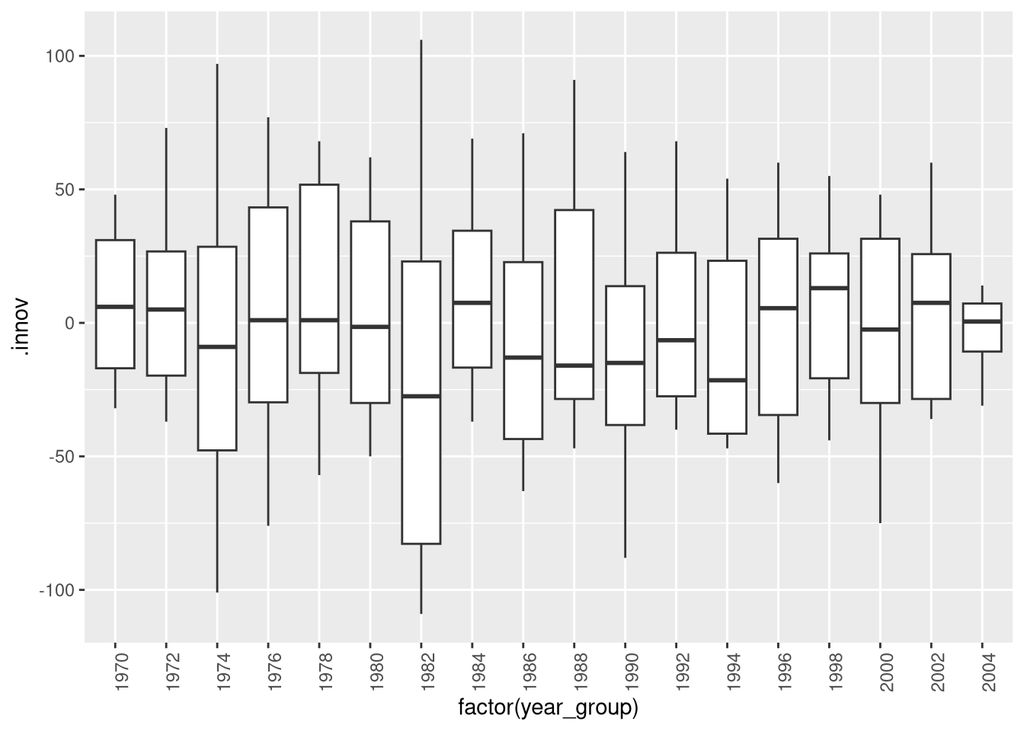

```r
model_vals |>

  # Select the appropriate model within model vals
  filter(.model == "Nv") |>

  ggplot(aes(x = factor(year_group), y = .innov)) +
  geom_boxplot() +
  theme(axis.text.x=element_text(angle = 90))
```

### Reading the four properties

1. **Autocorrelation:** clear. The spikes at multiples of the seasonal period (4, 8, 12, 16, 20…) show that the naive model has missed the seasonal pattern.
2. **Mean:** close to 0 (0.08). A t-test would say whether this is statistically different from zero; whether it matters in practice depends on the application. Either way, you could add it to the forecasts.
3. **Variance:** closer to constant than for the mean model. The 1974 and 1982-83 crises could be treated as outliers.
4. **Normality:** roughly normal. The histogram is symmetric and close to bell-shaped, the points follow the QQ line except at the tails, and the boxplot is symmetric with the mean close to the median.

# Example 2: Google stock

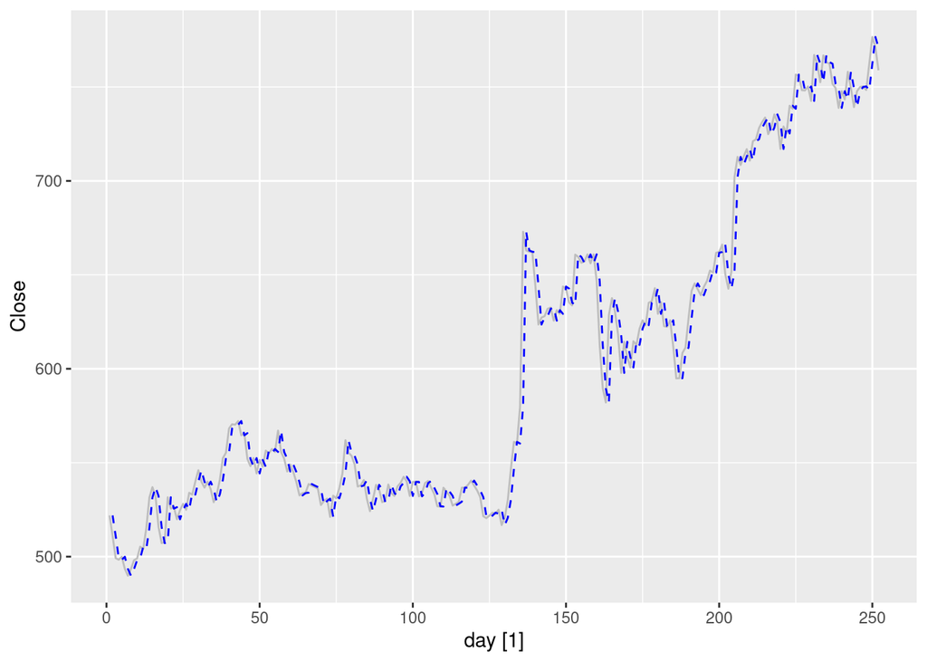

```r
# Re-index based on trading days
google_stock <- gafa_stock |>
  filter(Symbol == "GOOG", year(Date) >= 2015) |>
  mutate(day = row_number()) |>
  update_tsibble(index = day, regular = TRUE)

# Filter the year of interest
google_2015 <- google_stock |> filter(year(Date) == 2015)

# Fit the models
google_fit <- google_2015 |>
  model(
    Mean = MEAN(Close),
    Naive = NAIVE(Close)
  )

# Extract values from the mable:
model_vals <- google_fit |> augment()

# Plot fitted values for the NAIVE model:
model_vals |>
  filter(.model == "Naive") |>
  autoplot(Close, colour = "gray") +
  geom_line(aes(y=.fitted), colour = "blue", linetype = "dashed")
```

## Naive model

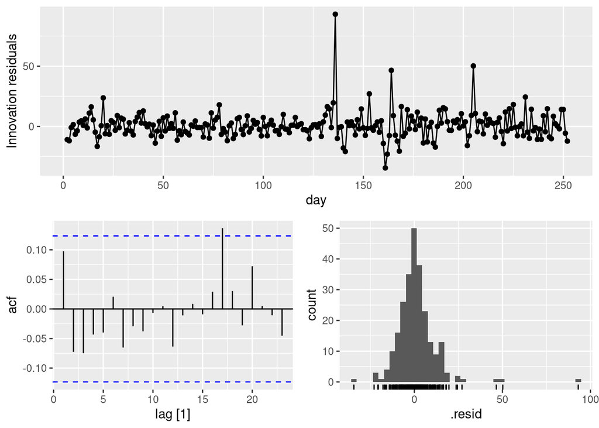

```r
google_fit |>
  select(Naive) |> # Selects the Naive model
  gg_tsresiduals()
```

```r
# Compute the mean of the residuals
model_vals |> as_tibble() |>
  filter(.model == "Naive") |>
  summarise(mean = mean(.innov, na.rm = TRUE))
```

```
# A tibble: 1 × 1
   mean
  <dbl>
1 0.944
```

A QQ plot and a boxplot of the residuals. The red dot in the boxplot is the mean.

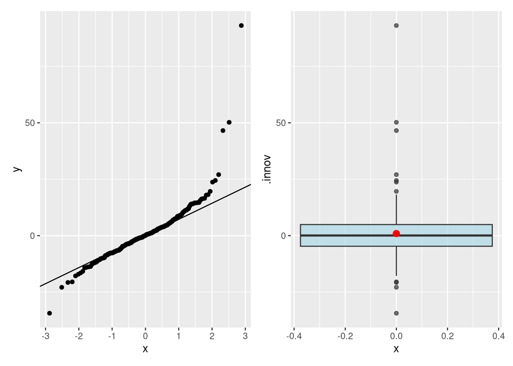

```r
mean_vals <- filter(model_vals, .model=="Naive")

# QQ plot
p1 <- ggplot(mean_vals, aes(sample = .innov))
p1 <- p1 + stat_qq() + stat_qq_line()

# Boxplot
p2 <- ggplot(data = mean_vals, aes(y = .innov)) +
      geom_boxplot(fill="light blue", alpha = 0.7) +
      stat_summary(aes(x=0), fun="mean", colour= "red") # Include the mean

p1 + p2
```

$$\text{residuals of the naive model:} \ \ \ \ y_t - y_{t-1}$$

As explained above, these residuals are often white noise for stock prices, which means the prices behave like a random walk.

## Mean model

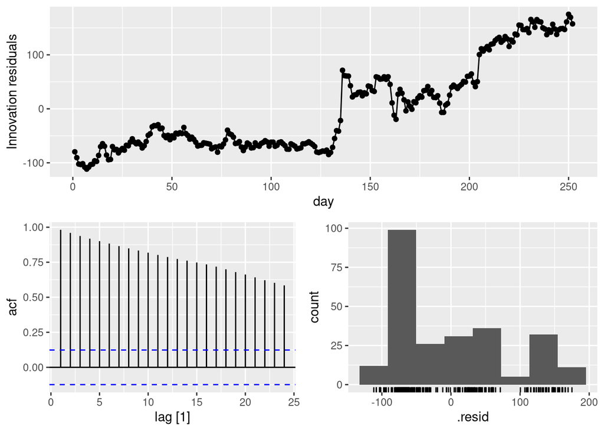

```r
google_fit |>
  select(Mean) |> # Selects the Mean model
  gg_tsresiduals()
```

```r
# Compute the mean of the residuals
model_vals |> as_tibble() |>
  filter(.model == "Mean") |>
  summarise(mean = mean(.innov, na.rm = TRUE))
```

```
# A tibble: 1 × 1
      mean
     <dbl>
1 2.71e-14
```

A QQ plot and a boxplot of the residuals. The red dot in the boxplot is the mean.

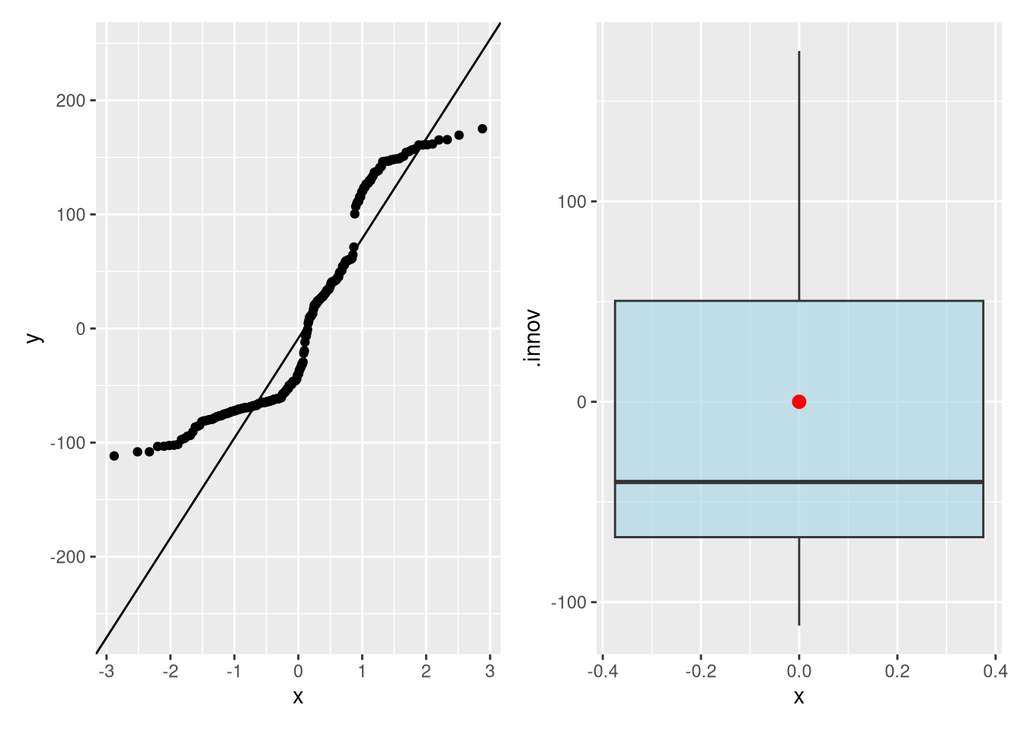

```r
mean_vals <- filter(model_vals, .model=="Mean")

# QQ plot
p1 <- ggplot(mean_vals, aes(sample = .innov))
p1 <- p1 + stat_qq() + stat_qq_line()

# Boxplot
p2 <- ggplot(data = mean_vals, aes(y = .innov)) +
      geom_boxplot(fill="light blue", alpha = 0.7) +
      stat_summary(aes(x=0), fun="mean", colour= "red") # Include the mean

p1 + p2
```

# Portmanteau tests for autocorrelation

Checking each bar of the ACF plot against the bounds is the same as running one hypothesis test per bar, each with a small chance of a false positive. Run enough tests and at least one false positive becomes likely. References 3 and 4 explain this multiple-testing problem.

The fix is one test on the first $l$ autocorrelations together: do they, as a group, look like white noise? A test on several autocorrelations at once is called a **portmanteau test**, from the French for a coat rack that carries several garments.

## Box-Pierce and Ljung-Box statistics

Two statistics are common:

**Box-Pierce Statistic**:

$$\begin{align*}
Q = T \sum_{k=1}^\ell r_k^2,
\end{align*}$$

- $l$ is the maximum lag being considered
- $T$ is the number of observations
- $r_k$ is the k-th autocorrelation coefficient

**Ljung-Box Statistic**

$$\begin{align*}
Q^* = T(T+2) \sum_{k=1}^\ell (T-k)^{-1}r_k^2.
\end{align*}$$

- $l$ is the maximum lag being considered
- $T$ is the number of observations
- $r_k$ is the k-th autocorrelation coefficient

## Why squaring

Both statistics measure the total amount of autocorrelation, instead of checking each coefficient on its own. Both **grow as the autocorrelation grows**, because every term in the sum contains $r_k^2$. Squaring does two things:

1. No term is negative, so nothing cancels. The more autocorrelation at any lag, the larger the statistic.
2. Small autocorrelations almost vanish, while medium and large ones stay large. Every $|r_k| \leq 1$, so squaring shrinks them all, but it shrinks the small ones most. Small, accidental correlations therefore add little to the statistic, while real structure dominates it.

Squaring appears in many statistics, so the effect is worth seeing with numbers:

- $0.9 * 0.9 = 0.81$ : the magnitude is reduced by 10% ($1 - 0.9 = 0.1$)
- $0.7 * 0.7 = 0.49$ : the magnitude is reduced by 30% ($1 - 0.7 = 0.3$)
- $0.5 * 0.5 = 0.25$ : the magnitude is reduced by 50% ($1 - 0.5 = 0.5$)
- $0.25 * 0.25 = 0.0625$ : the magnitude is reduced by 75% ($1-0.25 = 0.25$)
- $0.1 * 0.1 = 0.01$ : the magnitude is reduced by 90% ($1 - 0.1 = 0.9$)

In short, squaring makes every term of $Q$ and $Q^*$ non-negative, and it weights each autocorrelation by its size: if every $r_k$ is close to 0 the statistic is small, and if some $r_k$ are large, positive or negative, it is large.

## Choosing the lag

**The lag, $l$**, is the number of autocorrelations in the sum. fpp3 recommends:

- $l = 10$ for non-seasonal data
- $l = 2m$ for seasonal data, where $m$ is the period of seasonality
- **Caution:** the test is unreliable if $T/l < 5$. In that case use $l = T/5$.

**The distribution of the statistic.** We take one result as given: **if the series is white noise, $Q$ and $Q^*$ follow a $\chi^2$ distribution with $l$ degrees of freedom**, one for each autocorrelation in the sum.

## Reading the test

- $H_0$: the residuals are white noise. Then $Q$ and $Q^*$ follow a $\chi^2$ distribution with $l$ degrees of freedom.
- $H_1$: the residuals are not white noise.

The test is right-tailed. If the residuals are uncorrelated, the statistic should be small. A large statistic is unlikely under $H_0$, so we reject $H_0$ when the statistic is large enough, which is the same as a small p-value.

Choose a significance level $\alpha$, usually 0.05: the chance you accept of rejecting $H_0$ when it is true (a type I error). If the p-value is below $\alpha$, reject $H_0$; otherwise, do not reject it.

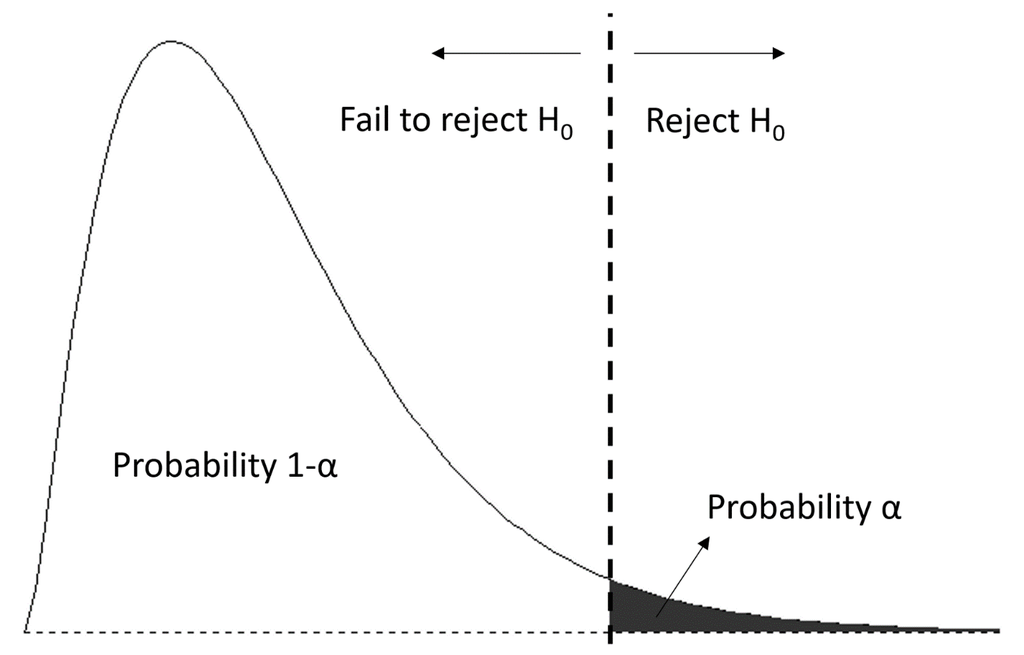

Right tailed test with Chi-squared distribution

## Running the test

`augment()` gives the residuals, and `features()` runs the test on the innovation residuals. The one argument to choose is `lag`: how many autocorrelations to include, **$l$ above.**

Back to the bricks models. The data is quarterly, so $m = 4$ and $l = 2m = 8$.

```r
bricks_aug <- bricks_fit |> augment()

bricks_aug |> filter(.model == "Nv") |> features(.innov, box_pierce, lag = 8)
```

```
# A tibble: 1 × 3
  .model bp_stat bp_pvalue
  <chr>    <dbl>     <dbl>
1 Nv        195.         0
```

```r
bricks_aug |> filter(.model == "Nv") |> features(.innov, ljung_box, lag = 8)
```

```
# A tibble: 1 × 3
  .model lb_stat lb_pvalue
  <chr>    <dbl>     <dbl>
1 Nv        206.         0
```

```r
bricks_aug |> filter(.model == "Mean") |> features(.innov, ljung_box, lag = 8)
```

```
# A tibble: 1 × 3
  .model lb_stat lb_pvalue
  <chr>    <dbl>     <dbl>
1 Mean      269.         0
```

Every p-value is 0 to the printed precision, far below 0.01, so we reject $H_0$ at the 1% level: neither model’s residuals are white noise. A p-value printed as 0 means smaller than the print precision, not exactly zero.

# Exercise 1

Analyze the residuals of the decomposition model from Exercise 1 in notebook *08_A_Benchmark_Methods_FittedVals*. This code plots the data and fits the model:

```
Plot variable not specified, automatically selected `.vars = Turnover`
```

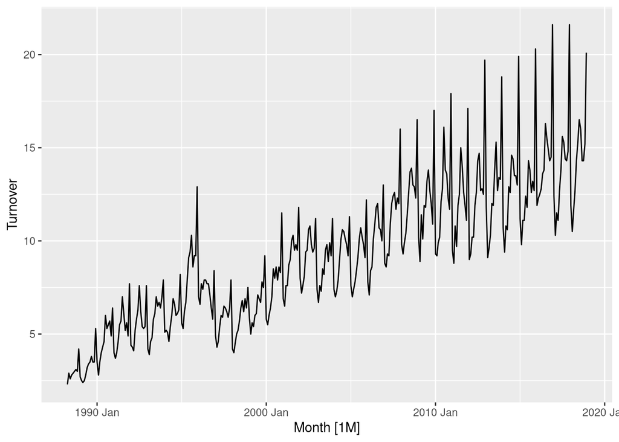

```r
retail_series <- aus_retail |>
  filter(`Series ID` == "A3349767W")

retail_series |> autoplot()
```

```r
fit_dcmp <- retail_series |>
  model(
    decomp = decomposition_model(
                # Specify the decomposition scheme to be used.
                STL(log(Turnover)),
                # Specify a model for the seasonally adjusted component (in this case, a drift).
                RW(season_adjust ~ drift()),
                # Specify a model for the seasonal component (unnecessary, since SNAIVE is the default).
                SNAIVE(season_year)
            )
  )

fit_dcmp
```

```
# A mable: 1 x 3
# Key:     State, Industry [1]
  State              Industry                                             decomp
  <chr>              <chr>                                               <model>
1 Northern Territory Clothing, footwear and personal … <STL decomposition model>
```

*We discuss solutions in class.*

# Exercise 2

1. Apply a naive method to the Australian Exports series from the dataset `global_economy`

```r
aus_exports <- filter(global_economy, Country == "Australia")
```

*We discuss solutions in class.*

2. Extract the fitted values and the residuals
3. Plot the fitted values
4. Analyze the residuals. Be brief and clear. Use a portmanteau test for autocorrelation.
5. What if you want to fit more than one model to more than one country of the `global_economy` dataset? Try fitting both a naive and a mean model to the countries in `c("Australia", "Spain", "Germany")`.